# Arbre couvrant de poids minimal

```python
import numpy as np
import pandas as pd
import time
import matplotlib.pyplot as plt
import networkx as nx
import sys
# Définiction d'une valeur infinie
Infiny=1e+100
```

## Outils de visualisation:

Pour une bonne visualisation de nos graphes, on va construire une fonction qui va dessine nos grahes.

```python
def draw_graph(X,U,check=False):
    G = nx.Graph()
    for k in X:
        G.add_node(k)

    temp=[]
    for a,b in U.keys():
        temp.append((a,b,U[a,b]))
    G.add_weighted_edges_from(temp)
    pos = nx.spring_layout(G, iterations=10,weight='weight')
    labels = nx.get_edge_attributes(G, 'weight')
    edges = G.edges()
    nx.draw(G, pos, edges=edges,with_labels=True,font_size=12,edge_labels=labels)
    d=nx.draw_networkx_edge_labels(G, pos, edge_labels=labels)
    plt.axis('off')
    plt.show()
    if check:
        xa=nx.minimum_spanning_tree(G)
        print("arbre minimal:{}".format(xa.size(weight="weight")))
```

## Algorithme de Kruskal:

### Définition des fonctions union et find et marquage:

Comme il a été préconiser d'utiliser ces fonctions pour l'implémentation de ces fonctions pour l'implémentation de Kruskal, on va d'abord définir ces deux fonctions. Comme structure de données, on utilise ici un dictionnaire pour représenter les arêtes avec leurs poids. On va avoir comme clé du dictionnaire le tuple formé par deux sommets et comme valeur le poid de l'arêt.

```python
def MarkSet(Parent,x):
    parent=Parent.copy()
    parent[x]=x
    return(parent)
```

```python
def Find(Parent,x):
    parent=Parent.copy()
    while parent[x]!=x:
        x=parent[x]
    return x
```

```python
def Union(Parent,x,y):
    parent=Parent.copy()
    xroot=Find(parent,x)
    yroot=Find(parent,y)
    parent[xroot]=yroot
    return(parent)
```

Ici, parent va être une racine d'un sommet x.

### Fontion Kruskal:

```python
def Kruskal(X,U):
    parent,poid,res = {},0,{}
    ## Initialisation par marquage
    for v in X:
        parent=MarkSet(parent,v)

    for k in range(len(X)-1):
        temp,x_min,y_min=Infiny,-Infiny,-Infiny
        for x,y in U.keys():
            p=U[x,y]
            if Find(parent,x) != Find(parent,y) and p<temp :
                temp,x_min,y_min=p,x,y
        parent=Union(parent,x_min,y_min)
        res[x_min,y_min]=temp
        poid+=temp
    return(res,poid)
```

### Application sur un petit graphe:

### Exemple de graphe du cours:

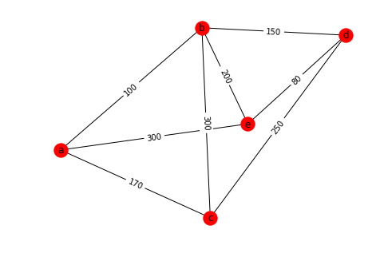

```
arbre minimal:500.0
```

```python
X=["a","b","c","d","e"]# Représente l'ensemble des sommets.

W={("a","b"):100,("b","a"):100,("a","c"):170,("c","a"):170,
  ("c","b"):300,("b","c"):300,("b","d"):150,("d","b"):150,
  ("b","e"):200,("e","b"):200,("c","d"):250,("d","c"):250,
  ("d","e"):80,("e","d"):80,("a","e"):300,("e","a"):300}# Représente l'ensemble des arêtes+poids.
draw_graph(X,W,check=True)
```

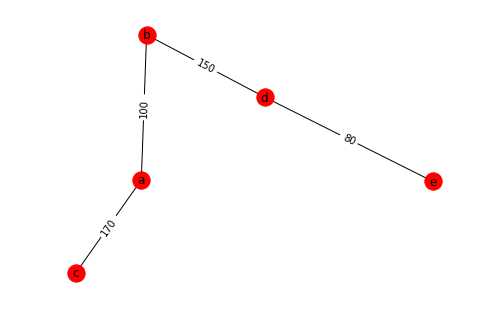

```
arbre minimal:500.0
Temps d'execution:0.1116487980
Le chemin avec poids={('d', 'e'): 80, ('a', 'b'): 100, ('b', 'd'): 150, ('a', 'c'): 170}
Distance total=500
```

```python
t=time.time()
chemin,poid_total=Kruskal(X,W)
draw_graph(X,chemin,check=True)
print("Temps d'execution:{:.10f}".format(time.time()-t))
print("Le chemin avec poids={}".format(chemin))
print("Distance total={}".format(poid_total))
```

## Optimisation de la fonction Kruskal selon les indications du cours:

Pour cela, on va recoder union de tel sorte à prendre la plus petite des deux arborescences comme enfant de la plus grande

```python
def Union_bis(Parent,poid,x,y):
    parent=Parent.copy()
    xroot=Find(parent,x)
    yroot=Find(parent,y)
    if xroot != yroot:
        if poid[xroot] > poid[yroot]:
            parent[yroot] = xroot
        else:
            parent[xroot] = yroot
            if poid[xroot]==poid[yroot]:
                poid[xroot]=poid[yroot]+1
    return(parent,poid)
```

```python
def Kruskal_opt(X,U):
    parent,poid,res = {},{},{}
    for v in X:
        parent=MarkSet(parent,v)
        poid[v]=0
    for k in range(len(X)-1):
        temp,x_min,y_min=Infiny,None,None
        for x,y in U.keys():
            p=U[x,y]
            if Find(parent,x) != Find(parent,y) and p<temp :
                temp,x_min,y_min=p,x,y
        if x_min is not None and y_min is not None:
            parent,poid=Union_bis(parent,poid,x_min,y_min)
            res[x_min,y_min]=temp

    return(res,sum(res.values()))
```

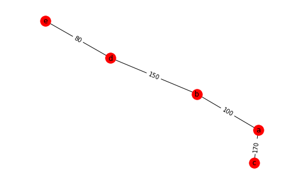

```
arbre minimal:500.0
Temps d'execution:0.0943505764
Le chemin avec poids={('d', 'e'): 80, ('a', 'b'): 100, ('b', 'd'): 150, ('a', 'c'): 170}
Distance total=500
```

```python
t=time.time()
chemin,poid_total=Kruskal_opt(X,W)
draw_graph(X,chemin,check=True)
print("Temps d'execution:{:.10f}".format(time.time()-t))
print("Le chemin avec poids={}".format(chemin))
print("Distance total={}".format(poid_total))
```

## Algorithme de Prim

```python
def Prim(X,V,s):
    cout,S,T,S_b=0,[s],{},X.copy()
    S_b.remove(s)
    Liste_arete={(j,i):V[i,j] for i,j in V.keys()}
    Liste_arete.update(V)
    for k in range(0,len(X)-1):
        mini,u_min,v_min=Infiny,None,None
        for u in S :
            for v in S_b:
                val_dist=Infiny
                if (u,v) in Liste_arete.keys():
                    val_dist=Liste_arete[u,v]
                if val_dist<mini:
                    mini,u_min,v_min=val_dist,u,v
        if u_min is not None and v_min is not None:
            S_b.remove(v_min)
            T[u_min,v_min]=mini
            S.append(v_min)
            cout=cout+mini

    return(T,cout)
```

### Application sur le même graphe que celui de Kruskal:

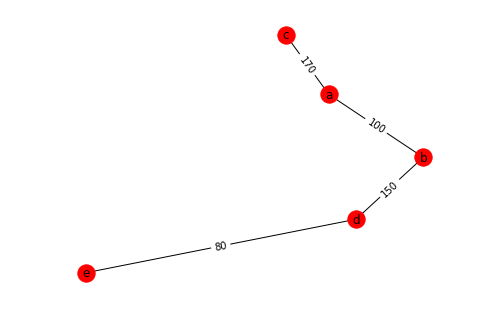

```
arbre minimal:500.0
Le chemin avec poids={('a', 'b'): 100, ('b', 'd'): 150, ('d', 'e'): 80, ('a', 'c'): 170}
Distance total=500
```

```python
chemin,poid_total=Prim(X,W,X[0])
draw_graph(X,chemin,check=True)
print("Le chemin avec poids={}".format(chemin))
print("Distance total={}".format(poid_total))
```

Sur l'exemple qu'on a pris comme référence, on peut constater que les deux algorithmes ont les mêmes résultats sur le poids total.

## Optimisation de l'algorithme de Prim selon la proposition d'algorithme faite en cours:

```python
def Prim_v3(X,V,s):
    nb_sommet=0
    S={k:False for k in X}
    S[s],arete,pred=True,{},{}
    X_plus=[s]
    X_moins=X.copy()
    X_moins.remove(s)
    Liste_arete={(j,i):V[i,j] for i,j in V.keys()}
    Liste_arete.update(V)
    while nb_sommet<len(X)-1:
        x,y,mini=None,None,Infiny
        for i in X_plus:
            if S[i]:
                for j in X_moins:
                    if not S[j] and (i,j) in Liste_arete:
                        poid=Liste_arete[i,j]
                        if mini>poid :
                            x,y,mini=i,j,poid
            else:
                break
        if y is not None:
            X_plus.append(y)
            X_moins.remove(y)
            S[y],arete[x,y]=True,mini
            pred[y]=x
        nb_sommet+=1
    return(arete,pred,sum(arete.values()))
```

## Application sur des grahes réels:

Chargement des données:

```python
graphes280=pd.read_table("a280.tsp.txt",header=None,sep="\s+")
graphes1000=pd.read_table("dsj1000.tsp.txt",header=None,sep="\s+")
graphes4461=pd.read_table("fnl4461.tsp.txt",header=None,sep="\s+")
graphes85900=pd.read_table("pla85900.tsp.txt",header=None,sep="\s+")
```

### Construction à partir de la base de données des sommets et des arêtes

```python
def load_graph(df):
    X=list(df.iloc[:,0])
    df=df.values
    G=[]
    for row in df:
        for k in df:
            if not np.array_equal(row,k):
                G.append([row[0],k[0],np.sqrt((k[1]-row[1])*(k[1]-row[1])+(k[2]-row[2])*(k[2]-row[2]))])
        df=np.delete(df, 0, 0)
    W={(a,b):c for a,b,c in G}

    return(X,W)

X_280,W_280=load_graph(graphes280)
X_1000,W_1000=load_graph(graphes1000)
X_4461,W_4461=load_graph(graphes4461)
#X_85900,W_85900=load_graph(graphes85900)
```

## Remarque:

Comme le calcul des poids des arêtes sur le graphe pla85900 fait planter mon PC à chaque fois que je tente de le lancer, je n'ai pas alors pu appliquer les algorithmes sur pla85900. Donc je reste que sur les trois autres graphes.

### Visualisation du graphe 280:

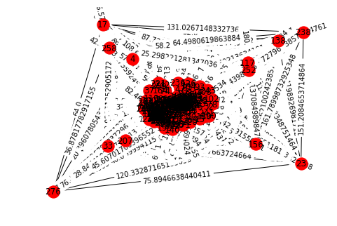

```
arbre minimal:2438.5667409622256
```

```python
draw_graph(X_280,W_280,check=True)
```

Avec une méthode déjà implémenté dans python on a domme distance total de l'arbre couvrante minimal 2438.56 pour le graphe a280. On va donc utiliser comme référence pour a280 cette valeur

### Application de l'algotithme de prime:

```python
t=time.time()
chemin_280,poid_total_280=Prim(X_280,W_280,X_280[0])
print("Temps d'execution:{:.10f}".format(time.time()-t))
print("Le chemin avec poids={}".format(chemin_280))
print("Distance total={}".format(poid_total_280))
```

```
Temps d'execution:3.0858895779
Le chemin avec poids={(1, 280): 17.88854381999832, (280, 2): 8.94427190999916, (280, 3): 10.0, (3, 279): 10.770329614269007, (279, 278): 8.94427190999916, (279, 4): 12.649110640673518, (4, 277): 10.0, (277, 276): 10.770329614269007, (276, 275): 8.0, (275, 274): 8.0, (274, 273): 8.0, (273, 272): 8.0,…
Distance total=2438.5667409622256
```

On constate que pour a280 l'algorithme de Prim s'execute en 3 secondes et donne la même distance que la référence qu'on obtenu avec une fonction interne à Python. On peut alors dire que notre algorithme fonctionne bien et nous donne des résultats fiables.

Prim sur 1000:

```python
t=time.time()
chemin_1000,poid_total_1000=Prim(X_1000,W_1000,X_1000[0])
print("Temps d'execution:{:.10f}".format(time.time()-t))
print("Le chemin avec poids={}".format(chemin_1000))
print("Distance total={}".format(poid_total_1000))
```

```
Temps d'execution:139.8860881329
Le chemin avec poids={(1, 914): 4327.649246415425, (1, 324): 10054.150685164808, (324, 300): 5759.611097982224, (300, 77): 8544.691275874162, (77, 971): 7653.8025190097505, (971, 757): 7592.49135659699, (757, 385): 8617.394327753605, (1, 817): 10986.961818446445, (817, 728): 876.3041709360969, (728,…
Distance total=15905257.207705608
```

En résumé pour le graphe à dsj1000, on a comme distance total de l'arbre couvrante minimale 15905257.207. Et l'algorithme à pris 139 secondes à s'executer, soit 2mn:19s

## Graphe fnl4461

```python
t=time.time()
chemin_4461,poid_total_4461=Prim(X_4461,W_4461,X_4461[0])
print("Temps d'execution:{:.10f}".format(time.time()-t))
print("Le chemin avec poids={}".format(chemin_4461))
print("Distance total={}".format(poid_total_4461))
```

```
Temps d'execution:11271.6556630135
Le chemin avec poids={(1, 4): 20.024984394500787, (4, 5): 10.0, (4, 13): 36.359317925395686, (13, 10): 28.319604517012593, (10, 12): 31.953090617340916, (12, 7): 21.470910553583888, (13, 23): 36.71511950137164, (23, 25): 21.93171219946131, (12, 14): 40.80441152620633, (5, 16): 50.44799302251776, (16…
Distance total=168722.23709099824
```

Le temps d'execution de l'algorithme est de 3h:7min:52s. avec le poid total de l'arbre couvrant qui vaut 168722.23 pour le graphe fnl4461.

## Visualisation des résultats:

## Graphe 280:

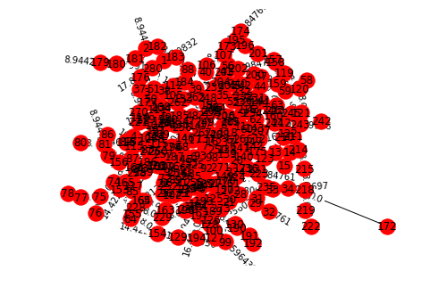

```
arbre minimal:2438.5667409622265
```

```python
draw_graph(X_280,chemin_280,check=True)
```

## Graphe 1000:

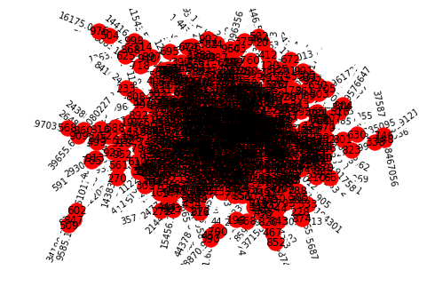

```
arbre minimal:15905257.207705624
```

```python
draw_graph(X_1000,chemin_1000,check=True)
```

## Gaphe 4461

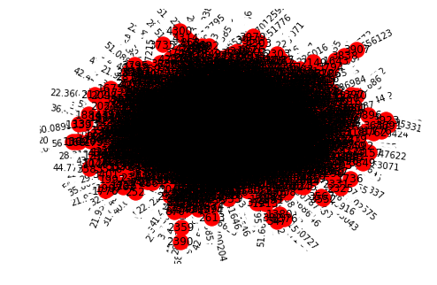

```
arbre minimal:168722.23709099845
```

```python
draw_graph(X_4461,chemin_4461,check=True)
```

### Application de l'algorithme de Kruskal:

Pour Kruskal, on ne va pas utiliser le graphe 4461 car le temps de calcul s'avers être trop long. On se basera dans cette partie que sur les deux graphes 280 et 1000.

```python
t=time.time()
chemin,poid_total=Kruskal_opt(X_280,W_280)
print("Temps d'execution:{:.10f}".format(time.time()-t))
print("Le chemin avec poids={}".format(chemin))
print("Distance total={}".format(poid_total))
```

```
Temps d'execution:133.9474229813
Le chemin avec poids={(171, 172): 0.0, (7, 8): 8.0, (8, 9): 8.0, (8, 10): 8.0, (10, 11): 8.0, (11, 12): 8.0, (12, 13): 8.0, (13, 14): 8.0, (13, 15): 8.0, (16, 271): 8.0, (17, 18): 8.0, (18, 19): 8.0, (18, 133): 8.0, (19, 20): 8.0, (19, 132): 8.0, (20, 21): 8.0, (20, 131): 8.0, (21, 128): 8.0, (21, 1…
Distance total=2438.5667409622242
```

Kruskal prend plus de temps que Prim au vu du fait qu'elle cherche à chaque fois la racine des sommets avec la fonction Find. Ce qui peut prendre un peu plus de temps.

### Kruskal sur le graphe à 1000 arêtes:

```python
t=time.time()
chemin,poid_total=Kruskal_opt(X_1000,W_1000)
print("Temps d'execution:{:.10f}".format(time.time()-t))
print("Le chemin avec poids={}".format(chemin))
print("Distance total={}".format(poid_total))
```

```
Temps d'execution:21228.2999870777
Le chemin avec poids={(637, 983): 679.9088174159826, (18, 364): 692.3445673940108, (33, 359): 755.4137938904743, (896, 997): 847.7169338877218, (728, 817): 876.3041709360969, (316, 334): 899.4498318416653, (551, 835): 1226.9800324373662, (47, 885): 1490.6649522947805, (963, 972): 1727.3520197110952,…
Distance total=15905257.207705617
```

## classification hiérarchique ascendante:

Dans cette partie, comme on veut 3 classes, pou l'implémentation de cette algorithme, on va réutiliser ce que l'on a fait sur Kruskal mais en itérant sur n-3 mais pas sur n-1.

```python
def CHA(X,U,n_class=3):
    if n_class<1:
        print("n_class<1, choisir n_class>1")
        sys.exit()
    parent,poid,res = {},{},{}
    for v in X:
        parent=MarkSet(parent,v)
        poid[v]=0
    for k in range(len(X)-n_class):
        temp,x_min,y_min=Infiny,None,None
        for x,y in U.keys():
            p=U[x,y]
            if Find(parent,x) != Find(parent,y) and p<temp :
                temp,x_min,y_min=p,x,y
        if x_min is not None and y_min is not None:
            parent,poid=Union_bis(parent,poid,x_min,y_min)
            res[x_min,y_min]=temp

    return(res,sum(res.values()))
```

## Test sur un petit graphe:

On va d'abord l'appliquer sur un petit graphe pour bien visualiser la construction des classes.

```python
Xt=["a","b","c","d","e","f","g"]
Ut={("a","b"):7,("b","c"):8,("c","e"):5,
   ("e","g"):9,("g","f"):11,("f","d"):6,
   ("d","a"):5,("d","b"):9,("b","e"):7,("e","f"):8,("d","e"):15}
```

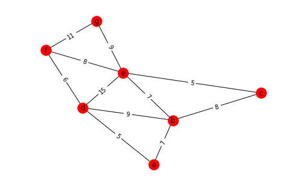

```python
draw_graph(Xt,Ut)
```

## Application de l'algorithme CHA:

```python
a,b=CHA(Xt,Ut,n_class=3)
```

### Visualisation

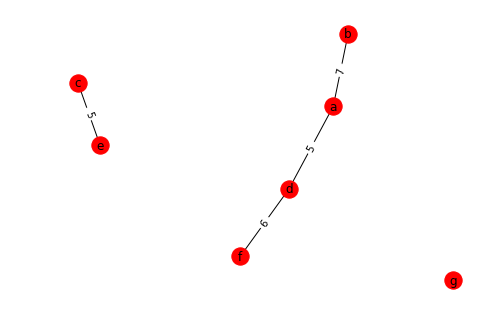

```python
draw_graph(Xt,a)
```

Comme on peut faire une vérification à la main, on remarque bien qu'on a les trois classes qu'il nous faut sur cette exemple.

## Application sur le graphe 1000:

```python
t=time.time()
chemin_cha1000,poid_total_cha1000=CHA(X_1000,W_1000,n_class=3)
print("Temps d'execution:{:.10f}".format(time.time()-t))
print("Le chemin avec poids={}".format(chemin_cha1000))
print("Distance total={}".format(poid_total_cha1000))
```

```
Temps d'execution:20329.5472483635
Le chemin avec poids={(637, 983): 679.9088174159826, (18, 364): 692.3445673940108, (33, 359): 755.4137938904743, (896, 997): 847.7169338877218, (728, 817): 876.3041709360969, (316, 334): 899.4498318416653, (551, 835): 1226.9800324373662, (47, 885): 1490.6649522947805, (963, 972): 1727.3520197110952,…
Distance total=15518306.59021013
```

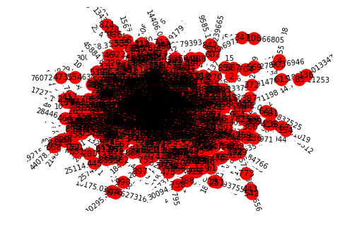

```
arbre minimal:15518306.590210134
```

```python
draw_graph(X_1000,chemin_cha1000,check=True)
```

Comme il y a trop de point on ne peut pas constater les 3 classes.

## Classification en 3 classes avec le graphe 280:

```python
t=time.time()
chemin_cha280,poid_total_cha280=CHA(X_280,W_280,n_class=3)
print("Temps d'execution:{:.10f}".format(time.time()-t))
print("Le chemin avec poids={}".format(chemin_cha280))
print("Distance total={}".format(poid_total_cha280))
```

```
Temps d'execution:147.1184661388
Le chemin avec poids={(171, 172): 0.0, (7, 8): 8.0, (8, 9): 8.0, (8, 10): 8.0, (10, 11): 8.0, (11, 12): 8.0, (12, 13): 8.0, (13, 14): 8.0, (13, 15): 8.0, (16, 271): 8.0, (17, 18): 8.0, (18, 19): 8.0, (18, 133): 8.0, (19, 20): 8.0, (19, 132): 8.0, (20, 21): 8.0, (20, 131): 8.0, (21, 128): 8.0, (21, 1…
Distance total=2404.1857746397554
```

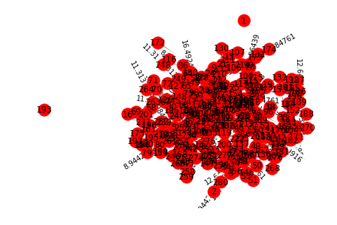

```
arbre minimal:2404.1857746397563
```

```python
draw_graph(X_280,chemin_cha280,check=True)
```

On a comme classe dans notre figure:

- Premier classe:{193}
- Deuxième classe:{1}
- Troisième classe: X-{1,193}

## Conculsion:

En temps de calcul, on remarque une augmentation exponentiel du temps de calcul au fur et à mesure où la volumetrie de nos données augmente. Et on peut aussi constater que Prim s'execute plus vite que Kruskal car Kruskal prend plus de temps lorsqu'on fait la recherche des racines avec la fonction Find.